# Part 3: Association Rules

Brenda Bor

2/4/2022

# Research Question

You are a Data analyst at Carrefour Kenya and are currently undertaking a project that will inform the marketing department on the most relevant marketing strategies that will result in the highest no. of sales (total price including tax). Your project has been divided into four parts where you’ll explore a recent marketing dataset by performing various unsupervised learning techniques and later providing recommendations based on your insights.

# Association Rules

This section will require that you create association rules that will allow you to identify relationships between variables in the dataset. You are provided with a separate dataset that comprises groups of items that will be associated with others. Just like in the other sections, you will also be required to provide insights for your analysis.

# Defining the question

## i)Specifying the Data Analytic Question

Create association rules that will allow you to identify relationships between variables in the dataset. You are provided with a separate dataset that comprises groups of items that will be associated with others.

## ii)Defining the Metric for Success

To be able to establish relationships between items in our dataset using the apriori algorithm.

## Understanding the context

Association analysis is an unsupervised method that is used to discover patterns that occur within a given dataset by identifying relationships between observations and variables from a dataset.

We use the apriori algorithm to build the association rules.

The 3 important measure parameters of association rules include;

1. Support- How popular an itemset is, as measured by the proportion of transactions in which an itemset appears
2. Confidence - How often one item A appears whenever another item B appears in a transaction. This is usually a conditional probability.
3. Lift- Used to measure the performance of the rule when compared against the entire data set.

Dataset link http://bit.ly/SupermarketDatasetII

# IMPLEMENTING THE SOLUTION

```r
# We first we install the required arules library
#
install.packages("arules")
# Loading the arules library
#
library(arules)
```

Loading our transactions dataset from our csv file

```r
# We will use read.transactions fuction which will load data from comma-separated files and convert them to the class transactions

path <-"http://bit.ly/SupermarketDatasetII"
df3<-read.transactions(path, sep = ",")
df3
```

```
## transactions in sparse format with
##  7501 transactions (rows) and
##  119 items (columns)
```

Verifying the object’s class

```r
# This should show us transactions as the type of data that we will need
class(df3)
```

```
## [1] "transactions"
## attr(,"package")
## [1] "arules"
```

```r
# Previewing our first 5 transactions
#
inspect(df3[1:5])
```

```
##     items
## [1] {almonds,
##      antioxydant juice,
##      avocado,
##      cottage cheese,
##      energy drink,
##      frozen smoothie,
##      green grapes,
##      green tea,
##      honey,
##      low fat yogurt,
##      mineral water,
##      olive oil,
##      salad,
##      salmon,
##      shrimp,
##      spinach,
##      tomato juice,
##      vegetables mix,
##      whole weat flour,
##      yams}
## [2] {burgers,
##      eggs,
##      meatballs}
## [3] {chutney}
## [4] {avocado,
##      turkey}
## [5] {energy bar,
##      green tea,
##      milk,
##      mineral water,
##      whole wheat rice}
```

Preview the first 10 items that make up our dataset

```r
# alternatively we can preview the items that make up our dataset
items<-as.data.frame(itemLabels(df3))
colnames(items) <- "Item"
head(items, 10)
```

```
##                 Item
## 1            almonds
## 2  antioxydant juice
## 3          asparagus
## 4            avocado
## 5        babies food
## 6              bacon
## 7     barbecue sauce
## 8          black tea
## 9        blueberries
## 10        body spray
```

Generating a summary of the sales dataset to get a sense of the most purchased items.

```r
#Summary
summary(df3)
```

```
## transactions as itemMatrix in sparse format with
##  7501 rows (elements/itemsets/transactions) and
##  119 columns (items) and a density of 0.03288973
##
## most frequent items:
## mineral water          eggs     spaghetti  french fries     chocolate
##          1788          1348          1306          1282          1229
##       (Other)
##         22405
##
## element (itemset/transaction) length distribution:
## sizes
##    1    2    3    4    5    6    7    8    9   10   11   12   13   14   15   16
## 1754 1358 1044  816  667  493  391  324  259  139  102   67   40   22   17    4
##   18   19   20
##    1    2    1
##
##    Min. 1st Qu.  Median    Mean 3rd Qu.    Max.
##   1.000   2.000   3.000   3.914   5.000  20.000
##
## includes extended item information - examples:
##              labels
## 1           almonds
## 2 antioxydant juice
## 3         asparagus
```

From the summary above, we can see that the most purchased item in our dataset is mineral water folloed by eggs.

Exploring the absolute and relative frequency of some items from some transactions

```r
# transacations ranging from 8 to 10 and performing
itemFrequency(df3[, 8:10],type = "absolute")
```

```
##   black tea blueberries  body spray
##         107          69          86
```

```r
round(itemFrequency(df3[, 8:10],type = "relative")*100,2)
```

```
##   black tea blueberries  body spray
##        1.43        0.92        1.15
```

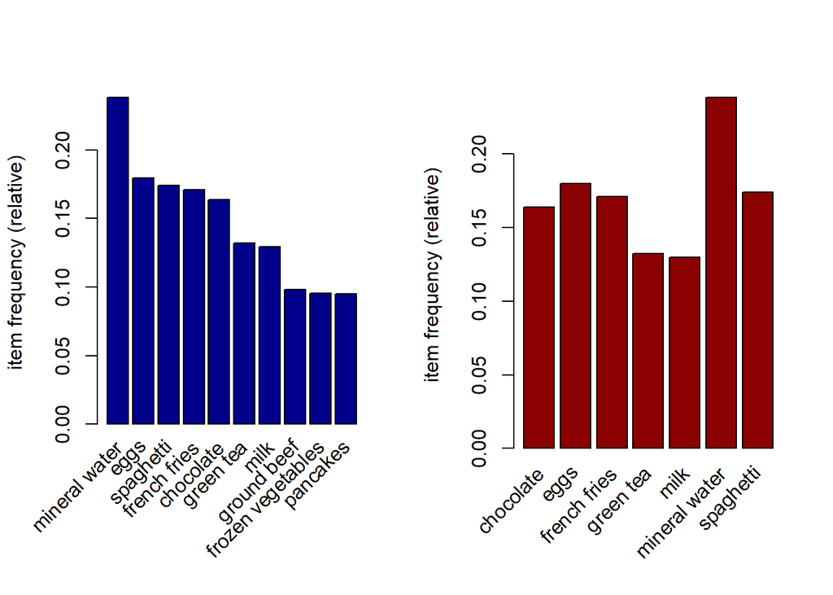

```r
par(mfrow = c(1, 2))

# plot the frequency of items
itemFrequencyPlot(df3, topN = 10,col="darkblue")
itemFrequencyPlot(df3, support = 0.1,col="darkred")
```

From the first graph we can see that mineral water, eggs,spaghetti were the most bought items.

From the seconf graph we can see that mineral water, eggs,spaghetti had the highest support